# Predicting Titanic Survivors using Logistic Regression

John Soler

31 March 2019

> Estimated Reading Time: 15-30 minutes

This project is carried out and presented here to display: my statistical knowledge particularly applied to Logistic Regression; my level of programming in R; and ability to explain and document advanced numerical techniques. I would consider this report as moderately technical and it is intended for an audience having a basic understanding of Regression as well as interest in some of the underlying concepts to this algorithm. The reader may skip all the code chunks if the programming aspect is not of interest.

The problem tackled here is to predict, as accurately as possible, the fate of a set of passengers on board the Titanic; whether they would survive or not (i.e. a binary classification problem). I obtained labelled data from Kaggle in the challenge “Titanic: Machine Learning from Disaster” (https://www.kaggle.com/c/titanic), and then applied my algorithm to a test set which also provided and evaluated by Kaggle.

## 1. Initialisation

The first section of the R code includes setting up packages, extracting data and making sure that the report is reproducible by setting a seed. The data is in CSV format and can be extracted directly from Kaggle, as well as from my GitHub account (as is done for this report).

```r
set.seed(200591)

packagesNeeded <- c("RCurl", "dplyr", "stringr", "ggplot2", "reshape"
                    , "glmnet", "caret", "car", "pROC", "knitr", "kableExtra")

for (i in packagesNeeded){
  if(!(i %in% installed.packages())){
    install.packages(i)
  }
  library(i, character.only = T)
}

rawTrain <- getURL("https://raw.githubusercontent.com/solerj/Kaggle_Titanic/master/train.csv")
trainO <- read.csv(text = rawTrain)
rawTest <- getURL("https://raw.githubusercontent.com/solerj/Kaggle_Titanic/master/test.csv")
testO <- read.csv(text = rawTest)

testO$Survived <- NA
dataAll <- rbind(trainO, testO)
```

## 2. Data Cleaning

First, here is the raw data with some information on each variable as described in Kaggle:

Data Description

| Variable | Description |
| --- | --- |
| PassengerId | Passenger Number |
| Survived | Survived or Not - the Target variable |
| Pclass | Class of Travel |
| Name | Name of Passenger |
| Sex | Gender |
| Age | Age of Passengers |
| SibSp | Number of Sibling/Spouse aboard |
| Parch | Number of Parent/Child aboard |
| Ticket | Ticket code |
| Fare | Fare |
| Cabin | Cabin code |
| Embarked | The port from which a passenger has embarked. C - Cherbourg, S - Southampton, Q = Queenstown |

Below is a summary of the structure of the table and the first few examples for each variable:

```
## 'data.frame':    1309 obs. of  12 variables:
##  $ PassengerId: int  1 2 3 4 5 6 7 8 9 10 ...
##  $ Survived   : int  0 1 1 1 0 0 0 0 1 1 ...
##  $ Pclass     : int  3 1 3 1 3 3 1 3 3 2 ...
##  $ Name       : Factor w/ 1307 levels "Abbing, Mr. Anthony",..: 109 191 358 277 16 559 520 629 417 581 ...
##  $ Sex        : Factor w/ 2 levels "female","male": 2 1 1 1 2 2 2 2 1 1 ...
##  $ Age        : num  22 38 26 35 35 NA 54 2 27 14 ...
##  $ SibSp      : int  1 1 0 1 0 0 0 3 0 1 ...
##  $ Parch      : int  0 0 0 0 0 0 0 1 2 0 ...
##  $ Ticket     : Factor w/ 929 levels "110152","110413",..: 524 597 670 50 473 276 86 396 345 133 ...
##  $ Fare       : num  7.25 71.28 7.92 53.1 8.05 ...
##  $ Cabin      : Factor w/ 187 levels "","A10","A14",..: 1 83 1 57 1 1 131 1 1 1 ...
##  $ Embarked   : Factor w/ 4 levels "","C","Q","S": 4 2 4 4 4 3 4 4 4 2 ...
```

A high level data cleaning is carried out. This includes preparing data types and some simple data manipulation as follows:

- Extracted the title of each passenger from the `Name` variable, and called the new feature `NameTitle`
- Filled in a few missing values for the `Fare` and `Embarked` variables
- Transformed the variables: `Pclass`, `Sex`, `Embarked` & `NameTitle` into factors. I made sure that for each variable, the most common level is labelled as the primary level. This is important in anticipation of fitting the regression model
- A quick analysis for any outliers was carried out and nothing noteworthy was detected

```r
# Passenger Names are written as: "Surname, Title. Name"
# I create a function to extract the Title from between the comma and fullstop
getTitle <- function(name) {
  firstTitle <- str_sub(name,
                        start = (str_locate(name, ',')[1]+2),
                        end = (str_locate(name, '[.]')[1]-1))
  firstTitle
}
dataAll$Name      <- as.character(dataAll$Name)
dataAll$NameTitle <- sapply(dataAll$Name, getTitle)


# I replace the missing Fare values by the median Fare for similar passengers
fareMissing <- dataAll[is.na(dataAll$Fare),]
fareQuickFill <- median(dataAll[dataAll$NameTitle == "Mr" &
                                  dataAll$Pclass == 3 &
                                  dataAll$Embarked == "S"
                                , c("Fare")], na.rm = T)
dataAll$Fare[is.na(dataAll$Fare)] <- fareQuickFill


# I replace the missing Embarked values by the most common embarkment for similar passengers
embarkedMissing <- dataAll[dataAll$Embarked == "",]
tbEmbark <- table(dataAll$Embarked[dataAll$Pclass == 1 &
                                     dataAll$SibSp == 0 &
                                     dataAll$Parch == 0])
modeEmbarked <- names(which.max(tbEmbark))
dataAll$Embarked[dataAll$Embarked == ""] <- modeEmbarked


# I create a function to change a variable type into factor, with the levels assigned in the same order of their frequency
myAsFactor <- function(tableName, variable){
  if(is.factor(tableName[,c(variable)])){
    tableName[,c(variable)] <- as.character(tableName[,c(variable)])
  }
  tb <- table(tableName[,c(variable)])
  factor(tableName[,c(variable)]
         , levels = names(tb[order(tb, decreasing = TRUE)]))
}

# Variables to be set as Factors
dataAll$SurvivedF <- myAsFactor(dataAll, "Survived")
variablesToRefactor <- c("Pclass", "Sex", "Embarked", "NameTitle")
for (variable in variablesToRefactor){
  dataAll[,c(variable)] <- myAsFactor(dataAll, variable)
}


# I create a function to compute the Chi-Square test of independence
# Since the data is not always distributed on all the levels evenly (some levels for some factors contain only a few data points), I incorporate a Monte Carlo technique using the simulate.p.value parameter
checkDependence <- function(variable1, variable2){
  contingency <- table(dataAll[,c(variable1, variable2)])
  chisq <- chisq.test(x = contingency, simulate.p.value = T)
  chisq$p.value
}
```

## 3. Data Exploration

In this section I investigate each variable in more detail, particularly in view of the Target variable. For each variable, I look for any relationship with the Target by using the Chi-Squared Test of Independence if the variable is categorical (e.g. Embarked) or using the Student’s t-Test if the variable is numerical (e.g. Fare). When categorical variables have a lot of levels, I consider grouping levels. I also apply scaling of numerical variables as necessary.

### Passenger Class

There are three Passenger Classes: 1, 2 and 3. The majority of the passengers are in the 3rd class, as one would expect, however there is also a considerable amount of passengers in the 2nd and 3rd classes. Plotting the Survival Rate of each class shows that there each class is correlated with the passengers’ survival. This observation is supported by a p-value of less than 0.05 for the Chi-Squared test for independence.

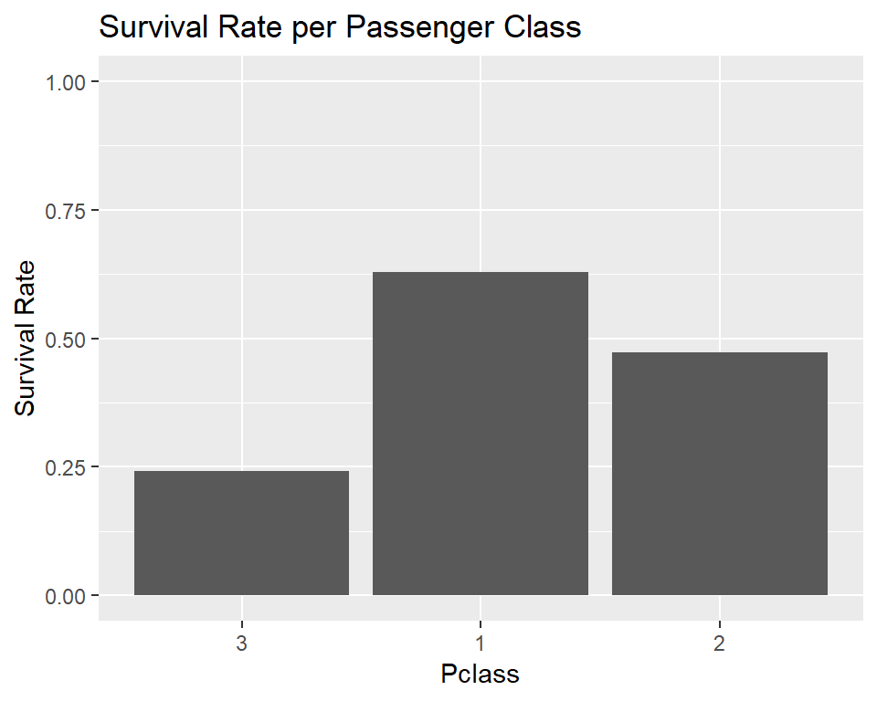

### Cabin Name

More information could have been extracted from the cabin name such as the cabin number, and time could have been spent on attempting to fill in the missing cabin names using information from other available variables. Such considerations were noted for future iterations of the project.

##### The First Cabin Letter

From the chart below it was immediately clear that there was some level of dependence between the survival of passengers and the first letter of their cabin. The different cabin letters may very well have referred to different locations or different floors on board the Titanic, for example, which could explain the relationship. It is good to note that only the captain was in cabin “T”, and he did not survive.

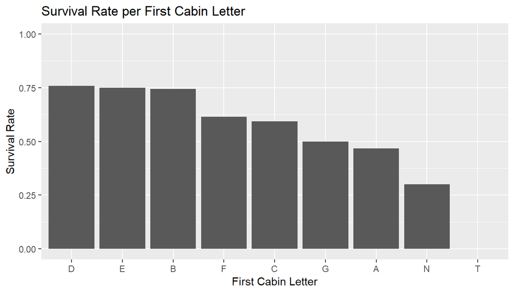

##### Number of Cabins

Most Passengers are associated with only one cabin. This includes all the passengers for whom we do not have the cabin information.

Distribution of Number of Cabins

| noCabins | SurvivalRate | Frequency |
| --- | --- | --- |
| 1 | 0.378316 | 1268 |
| 2 | 0.562500 | 26 |
| 3 | 0.500000 | 10 |
| 4 | 1.000000 | 5 |

The data hints that the higher the Number of Cabins, the higher the probability of survival. However, putting this hypothesis to the test returns a p-value of 0.1069465. The test rejects the hypothesis probably because there is not much data for `noCabins` greater than 1. To mitigate this, the `noCabins` variable is grouped into two levels, 1 and 2+, to form a new variable called `noCabinsGroup`. Applying the Chi-Squared test now returns a p-value of 0.0584708, which does not quite prove the level of confidence that one would wish for, however it is decided to still include this variable in the model while keeping a close eye on it.

### Title extracted from the Passenger Name

Certainly some work needs to be done on the `NameTitle` variable because, as shown in the table below, some of the levels appear only a few times or even once in the data. Including this variable as it is in a Regression model could risk overfitting. One easy improvement is to, once again, group some of the Titles.

Distribution of Titles

| NameTitle | SurvivalRate | Frequency |
| --- | --- | --- |
| Mr | 0.1566731 | 757 |
| Miss | 0.6978022 | 260 |
| Mrs | 0.7920000 | 197 |
| Master | 0.5750000 | 61 |
| Dr | 0.4285714 | 8 |
| Rev | 0.0000000 | 8 |
| Col | 0.5000000 | 4 |
| Major | 0.5000000 | 2 |
| Mlle | 1.0000000 | 2 |
| Ms | 1.0000000 | 2 |
| Capt | 0.0000000 | 1 |
| Don | 0.0000000 | 1 |
| Dona | NaN | 1 |
| Jonkheer | 0.0000000 | 1 |
| Lady | 1.0000000 | 1 |
| Mme | 1.0000000 | 1 |
| Sir | 1.0000000 | 1 |
| the Countess | 1.0000000 | 1 |

Indeed, after a quick search to understand which titles suggest similar signority and gender, and keeping an eye on the Survival Rate of each Title, grouping was done as follows:

- *Col*, *Don*, *Dr*, *Jonkheer*, *Major*, *Rev* and *Sir* were all grouped as *Dr*
- *Dona*, *Dr (female)*, *Lady*, *Mlle*, *Mme* and *the Coutness* were all grouped as *Mme*
- *Ms* and *Mrs* were grouped as *Mrs*

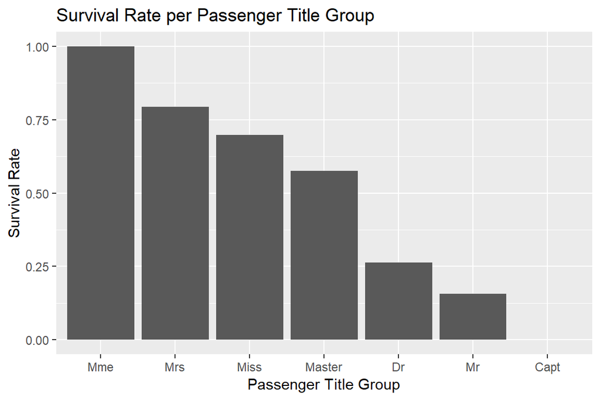

This results in less groups with more data points for each group. The Chi-Squared test confirms that there is some dependence between the `titleGroup` and Survival, plus with this new variable the risk of overfitting is reduced.

### Age

Upon investigating the `Age` variable, it is noticable that there is a considerable share of missing values. Before attempting to solve the issue of missing data, however, it would be wise to compare the `Age` variable against the newly created `titleGroup` variable because the `titleGroup` of the passenger may very well have a strong link with the `Age`.

Here is the summary for the `Age` variable:

```
##    Min. 1st Qu.  Median    Mean 3rd Qu.    Max.    NA's
##    0.17   21.00   28.00   29.88   39.00   80.00     263
```

It is suspected that `Age` and `titleGroup` are correlated. The chart below shows the Survival of passengers at different ages, split by the `titleGroup` (and `gender`). Except for the `titleGroup` “Master”, the `titleGroups` do not segment the passenger ages as much as one might have expected - many of the `titleGroups` have heavily operlapping passenger age brackets (i.e. not very related). Additionally, the line charts show no relationship between the Survival Rate and ages within each `titleGroup`. The line chart is plotted for different bucketing of the ages with the intention of visualising a range of plots from detailed to smoothened. None of these gives any clear indication of an existing relationship.

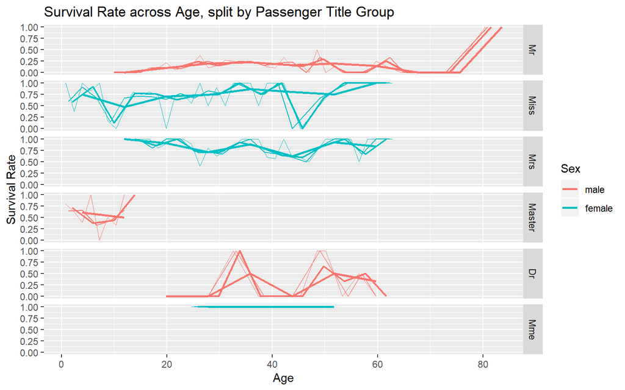

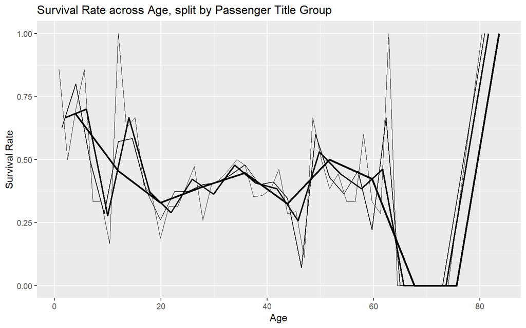

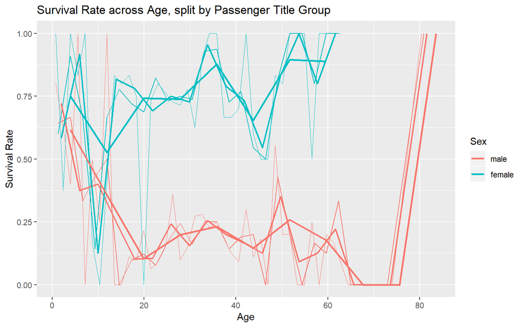

Despite the lack of evidence of correlation between `Age` and the probability of survival, the `Age` variable is still bucketed into a new variable called `ageBucket` and prepared so that it could be fit in the model later on. It is expected this variable will not add any significant information to the model, and it will also be used as an example to demonstrate how modelling techniques expose this automatically. The `Age` variable was bucketed into a categorical variable to increase the chances of it being significant; bucketing relaxes the linearity assumption (such as, for example, that propability of survival decreases as the age increases, which there is no evidence of) and avoids having to implement scaling of the variable. The below bucketing was selected after trying a few quick combinations.

Distribution of Age Group

| ageBucket | SurvivalRate | Frequency |
| --- | --- | --- |
| 15+ | 0.3852201 | 937 |
| NA | 0.2937853 | 263 |
| 0-3 | 0.6250000 | 34 |
| 3-6 | 0.8000000 | 22 |
| 9-12 | 0.2142857 | 19 |
| 12-15 | 0.6000000 | 18 |
| 6-9 | 0.5000000 | 16 |

### Embarking

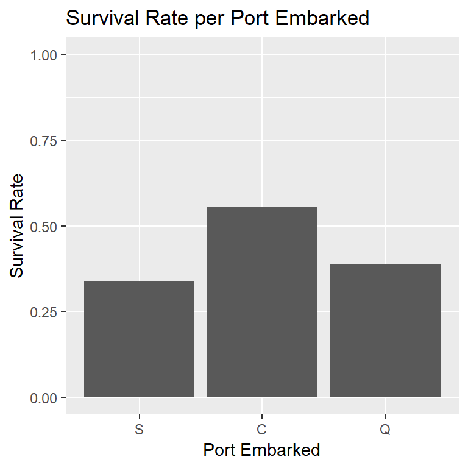

### Fare

```
##    Min. 1st Qu.  Median    Mean 3rd Qu.    Max.
##   0.000   7.896  14.454  33.276  31.275 512.329
```

It is important that the variable is transformed to be more symmetric, with moderate variance and with a range between 0 and 1.

Applying the natural log to the variable gives a much more normal-like distribution, which is expected to perform better with logistic regression. This also gives us the symmetry that we are looking for. Note that some passengers have a fare amount of $0, which is catered for by adding 1 before applying the log transformation. This transformed variable is saved as `logFare`.

The line chart of Survival Rate versus (binned) logFare gives strong evidence for a linear relationship between the two variables, which means that `logFare` is a promising variable for the logistic regression model. Next, `logFare` needs to be scaled ideally between 0 and 1.

[figure not shown]

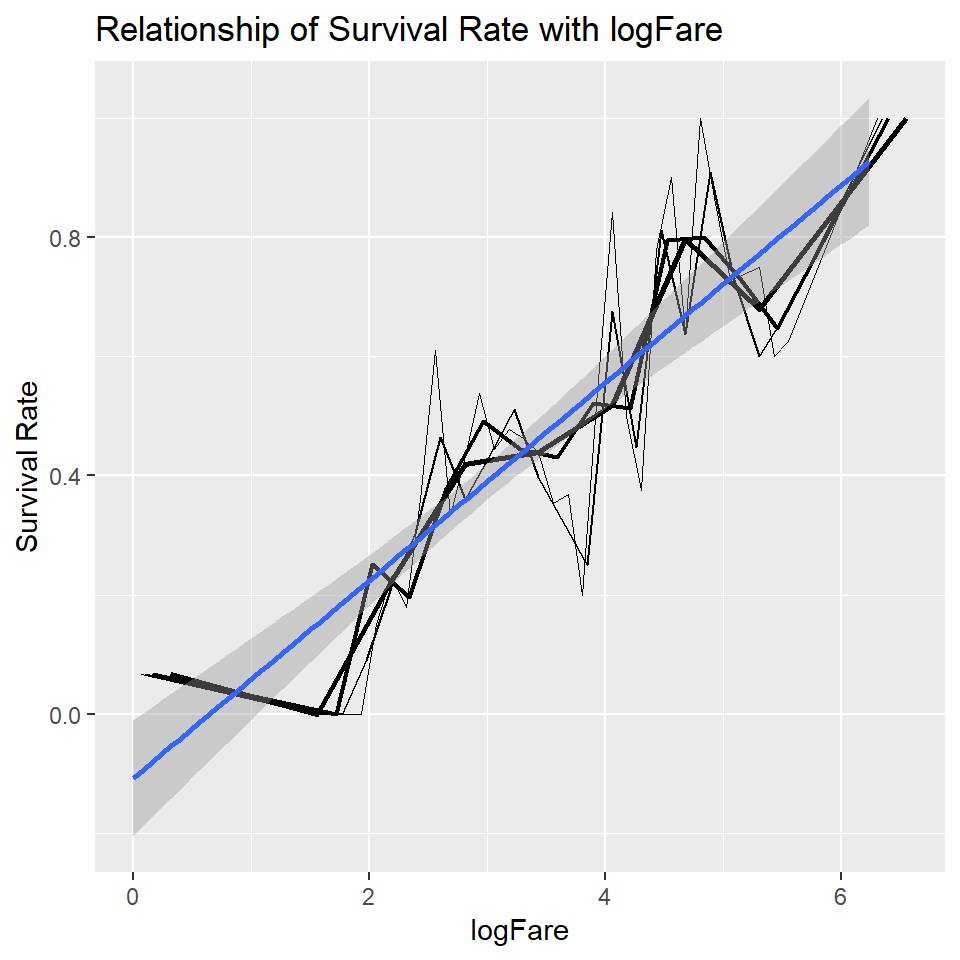

```
##    Min. 1st Qu.  Median    Mean 3rd Qu.    Max.
##  0.0000  0.3991  0.5000  0.5440  0.6345  1.1397
```

If we were, for some reason, to hypothesise that the relationship between `Fare` and Survival is different across `Sex` (such as we have seen for `Age`), one may plot a chart such as the below to get some insight. The chart shows two (practically) parallel lines at different y-intercepts. This means that the rate of change of Survival across the `logFare` is the same for each gender, so there is most probably no need to any interaction terms between the two. The difference between the y-intercepts will be taken care of by the `Sex` feature in the model.

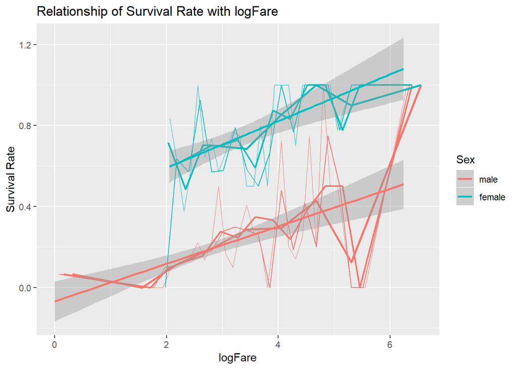

### Number of Parents or Children related to the Passenger onboard

The table below shows that some levels of `Parch` have low frequency and that some levels have similar survival rates; this immediately suggests that there is room for grouping some of the levels.

Distribution of Number of Parents/Children

| Parch | SurvivalRate | Frequency |
| --- | --- | --- |
| 0 | 0.3436578 | 1002 |
| 1 | 0.5508475 | 170 |
| 2 | 0.5000000 | 113 |
| 3 | 0.6000000 | 8 |
| 4 | 0.0000000 | 6 |
| 5 | 0.2000000 | 6 |
| 6 | 0.0000000 | 2 |
| 9 | NaN | 2 |

### Number of Siblings or Spouse related to the Passenger onboard

Finally, very similar to the transformation to the `Parch` variable, the `SibSp` is grouped into 4 groups: *0*, *1-2*, *3-4* and *5+*.

Distribution of Number of Siblings/Spouse

| SibSp | SurvivalRate | Frequency |
| --- | --- | --- |
| 0 | 0.3453947 | 891 |
| 1 | 0.5358852 | 319 |
| 2 | 0.4642857 | 42 |
| 4 | 0.1666667 | 22 |
| 3 | 0.2500000 | 20 |
| 8 | 0.0000000 | 9 |
| 5 | 0.0000000 | 6 |

## 4. Multi-Collinearity & Feature Selection

At this point, a Data Scientist may very well throw all the features into a Logistic Regression Model and use k-fold validation to add/remove features. For this report, I adopt a more controlled and deliberate (possibly less accurate) approach, which is likely to be more beneficial in a business setting since it gives more insight into the feature interactions and relevance to the final prediction. Here is the list of eligible features for the model:

`Pclass`, `Sex`, `cabinLetter`, `noCabinsGroup`, `titleGroup`, `ageBucket`, `Embarked`, `logFareS`, `parchGroup`, `sibspGroup`

```
## [[1]]
##
## Call:
## glm(formula = SurvivedF ~ ., family = binomial, data = myDf[,
##     c("SurvivedF", modelFeatures)])
##
## Deviance Residuals:
##     Min       1Q   Median       3Q      Max
## -2.4978  -0.5638  -0.4077   0.5344   2.4327
##
## Coefficients:
##                    Estimate Std. Error z value Pr(>|z|)
## (Intercept)        -2.90587    0.52075  -5.580 2.40e-08 ***
## Pclass1             1.17312    0.58412   2.008   0.0446 *
## Pclass2             0.60860    0.30366   2.004   0.0450 *
## cabinLetterC        0.02817    0.59906   0.047   0.9625
## cabinLetterB        0.77420    0.66413   1.166   0.2437
## cabinLetterD        0.92433    0.64352   1.436   0.1509
## cabinLetterE        1.28546    0.62757   2.048   0.0405 *
## cabinLetterA        0.73717    0.79450   0.928   0.3535
## cabinLetterF        0.54821    1.05885   0.518   0.6046
## cabinLetterG       -1.02787    1.09840  -0.936   0.3494
## cabinLetterT      -15.62679 2399.54477  -0.007   0.9948
## noCabinsGroup2+    -0.37981    0.71012  -0.535   0.5928
## titleGroupMiss      2.95996    0.30838   9.599  < 2e-16 ***
## titleGroupMrs       3.54743    0.37698   9.410  < 2e-16 ***
## titleGroupMaster    3.64684    0.76602   4.761 1.93e-06 ***
## titleGroupDr        0.09149    0.60657   0.151   0.8801
## titleGroupMme      16.52208  971.21151   0.017   0.9864
## titleGroupCapt    -15.80377 2399.54480  -0.007   0.9947
## ageBucket0-3        0.47570    0.75200   0.633   0.5270
## ageBucket3-6        1.71462    0.87723   1.955   0.0506 .
## ageBucket9-12      -1.33904    0.96757  -1.384   0.1664
## ageBucket12-15     -0.03639    0.89755  -0.041   0.9677
## ageBucket6-9        0.22129    1.03309   0.214   0.8304
## EmbarkedC           0.47415    0.30749   1.542   0.1231
## EmbarkedQ          -0.44443    0.53998  -0.823   0.4105
## logFareS            1.20781    1.18810   1.017   0.3094
## parchGroup1_3      -0.38216    0.36691  -1.042   0.2976
## parchGroup2         0.06453    0.48770   0.132   0.8947
```

[output cut: 12 more lines]

```
##
## Number of Fisher Scoring iterations: 15
##
##
## [[2]]
##                   GVIF Df GVIF^(1/(2*Df))
## Pclass        6.962153  2        1.624373
## cabinLetter   6.327116  8        1.122213
## titleGroup    4.383125  6        1.131050
## ageBucket     4.078816  5        1.150942
## logFareS      3.378417  1        1.838047
## parchGroup    2.682582  3        1.178760
## sibspGroup    2.543293  3        1.168331
## Embarked      1.457325  2        1.098725
## noCabinsGroup 1.391762  1        1.179730
```

```
##       cabinLetter
## Pclass   N   C   B   D   E   A   F   G   T
##      3 693   0   0   0   3   0   8   5   0
##      1  67  94  65  40  34  22   0   0   1
##      2 254   0   0   6   4   0  13   0   0
```

```
## [1] 0.0004997501
```

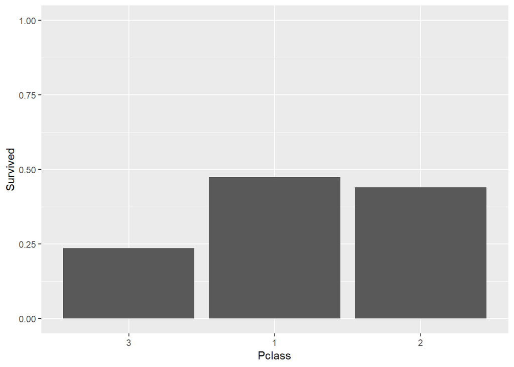

```
##
##   3   2   C   1   B   D   E   A   F   G   T
## 693 254  94  67  65  46  41  22  21   5   1
```

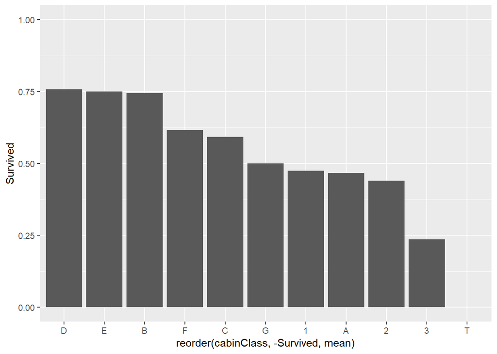

```
## [[1]]
##
## Call:
## glm(formula = SurvivedF ~ ., family = binomial, data = myDf[,
##     c("SurvivedF", modelFeatures)])
##
## Deviance Residuals:
##     Min       1Q   Median       3Q      Max
## -2.6576  -0.5642  -0.4023   0.5348   2.4484
##
## Coefficients:
##                    Estimate Std. Error z value Pr(>|z|)
## (Intercept)        -2.94625    0.51011  -5.776 7.66e-09 ***
## cabinClass2         0.63575    0.30861   2.060 0.039392 *
## cabinClassC         1.21689    0.56147   2.167 0.030209 *
## cabinClass1         1.32150    0.61871   2.136 0.032687 *
## cabinClassB         1.98575    0.62908   3.157 0.001596 **
## cabinClassD         2.03651    0.61329   3.321 0.000898 ***
## cabinClassE         2.36502    0.57614   4.105 4.04e-05 ***
## cabinClassA         1.94650    0.73399   2.652 0.008003 **
## cabinClassF         1.01907    1.00390   1.015 0.310051
## cabinClassG        -1.01702    1.09879  -0.926 0.354661
## cabinClassT       -14.43497 2399.54475  -0.006 0.995200
## noCabinsGroup2+    -0.45101    0.70067  -0.644 0.519781
## titleGroupMiss      2.96679    0.30925   9.594  < 2e-16 ***
## titleGroupMrs       3.52952    0.37604   9.386  < 2e-16 ***
## titleGroupMaster    3.63828    0.76731   4.742 2.12e-06 ***
## titleGroupDr        0.05161    0.60872   0.085 0.932430
## titleGroupMme      16.53092  970.33862   0.017 0.986408
## titleGroupCapt    -15.85564 2399.54480  -0.007 0.994728
## ageBucket0-3        0.47547    0.75116   0.633 0.526749
## ageBucket3-6        1.70265    0.87497   1.946 0.051661 .
## ageBucket9-12      -1.34339    0.96651  -1.390 0.164548
## ageBucket12-15     -0.02182    0.89814  -0.024 0.980619
## ageBucket6-9        0.15620    1.04436   0.150 0.881110
## EmbarkedC           0.45820    0.30877   1.484 0.137818
## EmbarkedQ          -0.42620    0.54134  -0.787 0.431099
## logFareS            1.24080    1.15537   1.074 0.282847
## parchGroup1_3      -0.37145    0.36771  -1.010 0.312422
## parchGroup2         0.08668    0.48806   0.178 0.859033
```

[output cut: 11 more lines]

```
## AIC: 630.67
##
## Number of Fisher Scoring iterations: 15
##
##
## [[2]]
##                   GVIF Df GVIF^(1/(2*Df))
## cabinClass    5.085391 10        1.084716
## titleGroup    4.403735  6        1.131493
## ageBucket     4.068409  5        1.150648
## logFareS      3.188719  1        1.785698
## parchGroup    2.685758  3        1.178993
## sibspGroup    2.566628  3        1.170111
## Embarked      1.472995  2        1.101667
## noCabinsGroup 1.395335  1        1.181243
```

```
##           ageBucket
## titleGroup 15+ 0-3 3-6 9-12 12-15 6-9
##     Mr     576   0   0    1     4   0
##     Miss   160  16  12    8     8   6
##     Mrs    170   0   0    0     1   0
##     Master   0  18  10   10     5  10
##     Dr      23   0   0    0     0   0
##     Mme      7   0   0    0     0   0
##     Capt     1   0   0    0     0   0
```

```
##           ageBucket
## titleGroup 15+ 0-3 3-6 9-12 12-15 6-9
##     Mr     395   0   0    1     2   0
##     Miss   108  10  11    6     6   5
##     Mrs    108   0   0    0     1   0
##     Master   0  14   9    7     1   5
##     Dr      18   0   0    0     0   0
##     Mme      6   0   0    0     0   0
##     Capt     1   0   0    0     0   0
```

```
## [[1]]
##
## Call:
## glm(formula = SurvivedF ~ ., family = binomial, data = myDf[,
##     c("SurvivedF", modelFeatures)])
##
## Deviance Residuals:
##     Min       1Q   Median       3Q      Max
## -2.6249  -0.5720  -0.3967   0.5689   2.4435
##
## Coefficients:
##                    Estimate Std. Error z value Pr(>|z|)
## (Intercept)        -2.93348    0.50613  -5.796 6.80e-09 ***
## cabinClass2         0.68685    0.30271   2.269 0.023268 *
## cabinClassC         1.25326    0.55510   2.258 0.023963 *
## cabinClass1         1.35920    0.61686   2.203 0.027565 *
## cabinClassB         2.00998    0.62671   3.207 0.001340 **
## cabinClassD         2.05557    0.60963   3.372 0.000747 ***
## cabinClassE         2.39674    0.57617   4.160 3.19e-05 ***
## cabinClassA         1.99425    0.72924   2.735 0.006244 **
## cabinClassF         1.28898    0.95238   1.353 0.175917
## cabinClassG        -0.53368    1.06079  -0.503 0.614896
## cabinClassT       -14.37211 2399.54475  -0.006 0.995221
## noCabinsGroup2+    -0.55433    0.68059  -0.814 0.415374
## titleGroupMiss      3.04404    0.28788  10.574  < 2e-16 ***
## titleGroupMrs       3.44729    0.36049   9.563  < 2e-16 ***
## titleGroupMaster    3.86634    0.61835   6.253 4.03e-10 ***
## titleGroupDr        0.04515    0.60724   0.074 0.940735
## titleGroupMme      16.54526  968.61670   0.017 0.986372
## titleGroupCapt    -15.97876 2399.54480  -0.007 0.994687
## EmbarkedC           0.47959    0.29895   1.604 0.108653
## EmbarkedQ          -0.44249    0.53466  -0.828 0.407893
## logFareS            1.12569    1.14338   0.985 0.324855
## parchGroup1_3      -0.24137    0.33555  -0.719 0.471948
## parchGroup2         0.04284    0.44109   0.097 0.922629
## parchGroup4+       -2.82344    1.15070  -2.454 0.014141 *
## sibspGroup1_2      -0.30162    0.27230  -1.108 0.267993
## sibspGroup3_4      -2.30973    0.61577  -3.751 0.000176 ***
## sibspGroup5+      -17.66812  923.18149  -0.019 0.984731
## ---
## Signif. codes:  0 '***' 0.001 '**' 0.01 '*' 0.05 '.' 0.1 ' ' 1
##
## (Dispersion parameter for binomial family taken to be 1)
##
##     Null deviance: 964.52  on 713  degrees of freedom
## Residual deviance: 576.69  on 687  degrees of freedom
## AIC: 630.69
##
## Number of Fisher Scoring iterations: 15
##
##
## [[2]]
##                   GVIF Df GVIF^(1/(2*Df))
## cabinClass    4.648514 10        1.079856
## logFareS      3.151051  1        1.775120
## titleGroup    2.673121  6        1.085388
## sibspGroup    2.275161  3        1.146838
## parchGroup    2.224302  3        1.142525
## Embarked      1.381324  2        1.084111
## noCabinsGroup 1.349047  1        1.161485
```

```
## [[1]]
##
## Call:
## glm(formula = SurvivedF ~ ., family = binomial, data = myDf[,
##     c("SurvivedF", modelFeatures)])
##
## Deviance Residuals:
##     Min       1Q   Median       3Q      Max
## -2.5631  -0.5622  -0.3865   0.5603   2.6099
##
## Coefficients:
##                    Estimate Std. Error z value Pr(>|z|)
## (Intercept)        -3.37194    0.45527  -7.406 1.30e-13 ***
## cabinClass2         0.72180    0.27951   2.582 0.009811 **
## cabinClassC         1.19981    0.49083   2.444 0.014508 *
## cabinClass1         0.84943    0.53279   1.594 0.110867
## cabinClassB         1.79939    0.58524   3.075 0.002108 **
## cabinClassD         2.06559    0.57369   3.601 0.000318 ***
## cabinClassE         2.27000    0.54854   4.138 3.50e-05 ***
## cabinClassA         1.45103    0.65770   2.206 0.027369 *
## cabinClassF         1.22854    0.85661   1.434 0.151520
## cabinClassG        -0.35223    1.04992  -0.335 0.737263
## cabinClassT       -14.54438 2399.54474  -0.006 0.995164
## noCabinsGroup2+    -0.43143    0.67416  -0.640 0.522206
## titleGroupMiss      3.08643    0.26144  11.806  < 2e-16 ***
## titleGroupMrs       3.43171    0.32912  10.427  < 2e-16 ***
## titleGroupMaster    4.05004    0.59396   6.819 9.19e-12 ***
## titleGroupDr        0.01249    0.57885   0.022 0.982778
## titleGroupMme      16.58422  970.46793   0.017 0.986366
## titleGroupCapt    -15.89711 2399.54479  -0.007 0.994714
## EmbarkedC           0.38592    0.26131   1.477 0.139714
## EmbarkedQ           0.25166    0.34270   0.734 0.462742
## logFareS            2.05532    1.00922   2.037 0.041697 *
## parchGroup1_3      -0.40401    0.32472  -1.244 0.213429
## parchGroup2        -0.31356    0.40643  -0.771 0.440418
## parchGroup4+       -3.07345    1.13543  -2.707 0.006792 **
## sibspGroup1_2      -0.29764    0.25190  -1.182 0.237384
## sibspGroup3_4      -2.58468    0.59630  -4.335 1.46e-05 ***
## sibspGroup5+      -17.25888  561.28711  -0.031 0.975470
## ---
## Signif. codes:  0 '***' 0.001 '**' 0.01 '*' 0.05 '.' 0.1 ' ' 1
##
## (Dispersion parameter for binomial family taken to be 1)
##
##     Null deviance: 1186.66  on 890  degrees of freedom
## Residual deviance:  705.88  on 864  degrees of freedom
## AIC: 759.88
##
## Number of Fisher Scoring iterations: 15
##
##
## [[2]]
##                   GVIF Df GVIF^(1/(2*Df))
## cabinClass    4.369690 10        1.076521
## logFareS      2.948354  1        1.717077
## titleGroup    2.724686  6        1.087117
## sibspGroup    2.217928  3        1.141978
## parchGroup    2.090970  3        1.130814
## Embarked      1.404268  2        1.088585
## noCabinsGroup 1.359714  1        1.166068
```

```
## [[1]]
##
## Call:
## glm(formula = SurvivedF ~ ., family = binomial, data = myDf[,
##     c("SurvivedF", modelFeatures)])
##
## Deviance Residuals:
##     Min       1Q   Median       3Q      Max
## -2.3001  -0.5406  -0.4500   0.5926   2.9210
##
## Coefficients:
##                    Estimate Std. Error z value Pr(>|z|)
## (Intercept)        -4.25187    0.41202 -10.319  < 2e-16 ***
## noCabinsGroup2+    -0.07928    0.66076  -0.120 0.904496
## titleGroupMiss      2.96154    0.25126  11.787  < 2e-16 ***
## titleGroupMrs       3.35990    0.31646  10.617  < 2e-16 ***
## titleGroupMaster    3.98125    0.58086   6.854 7.18e-12 ***
## titleGroupDr        0.18031    0.56118   0.321 0.747982
## titleGroupMme      17.08875  957.79033   0.018 0.985765
## titleGroupCapt    -15.27630 2399.54474  -0.006 0.994920
## EmbarkedC           0.30623    0.24738   1.238 0.215763
## EmbarkedQ           0.03567    0.32890   0.108 0.913642
## logFareS            5.07483    0.75148   6.753 1.45e-11 ***
## parchGroup1_3      -0.49220    0.30941  -1.591 0.111661
## parchGroup2        -0.60735    0.39619  -1.533 0.125283
## parchGroup4+       -3.91323    1.11957  -3.495 0.000474 ***
## sibspGroup1_2      -0.50923    0.24217  -2.103 0.035481 *
## sibspGroup3_4      -3.27386    0.58606  -5.586 2.32e-08 ***
## sibspGroup5+      -18.23013  561.06746  -0.032 0.974080
## ---
## Signif. codes:  0 '***' 0.001 '**' 0.01 '*' 0.05 '.' 0.1 ' ' 1
##
## (Dispersion parameter for binomial family taken to be 1)
##
##     Null deviance: 1186.66  on 890  degrees of freedom
## Residual deviance:  735.53  on 874  degrees of freedom
## AIC: 769.53
##
## Number of Fisher Scoring iterations: 15
##
##
## [[2]]
##                   GVIF Df GVIF^(1/(2*Df))
## titleGroup    2.400965  6        1.075719
## sibspGroup    2.043907  3        1.126532
## parchGroup    1.865046  3        1.109468
## logFareS      1.520505  1        1.233088
## Embarked      1.233670  2        1.053901
## noCabinsGroup 1.155993  1        1.075171
```

```
## [[1]]
##
## Call:
## glm(formula = SurvivedF ~ ., family = binomial, data = myDf[,
##     c("SurvivedF", modelFeatures)])
##
## Deviance Residuals:
##     Min       1Q   Median       3Q      Max
## -2.6953  -0.5544  -0.3853   0.5589   2.3449
##
## Coefficients:
##                    Estimate Std. Error z value Pr(>|z|)
## (Intercept)        -2.56345    0.20380 -12.578  < 2e-16 ***
## cabinClass2         0.88815    0.26729   3.323 0.000891 ***
## cabinClassC         1.80672    0.39000   4.633 3.61e-06 ***
## cabinClass1         1.38103    0.44777   3.084 0.002041 **
## cabinClassB         2.30852    0.50157   4.603 4.17e-06 ***
## cabinClassD         2.55572    0.52313   4.885 1.03e-06 ***
## cabinClassE         2.71580    0.50914   5.334 9.60e-08 ***
## cabinClassA         1.89872    0.61097   3.108 0.001885 **
## cabinClassF         1.26656    0.83777   1.512 0.130580
## cabinClassG        -0.43700    1.04685  -0.417 0.676350
## cabinClassT       -14.00262 2399.54473  -0.006 0.995344
## noCabinsGroup2+    -0.29409    0.65797  -0.447 0.654895
## titleGroupMiss      3.10456    0.25928  11.974  < 2e-16 ***
## titleGroupMrs       3.45307    0.32823  10.520  < 2e-16 ***
## titleGroupMaster    4.02926    0.59607   6.760 1.38e-11 ***
## titleGroupDr       -0.03716    0.57688  -0.064 0.948633
## titleGroupMme      16.65473  974.86862   0.017 0.986370
## titleGroupCapt    -15.92956 2399.54479  -0.007 0.994703
## EmbarkedC           0.46829    0.25700   1.822 0.068439 .
## EmbarkedQ           0.26591    0.34421   0.773 0.439798
## parchGroup1_3      -0.26175    0.31599  -0.828 0.407479
## parchGroup2        -0.08655    0.39043  -0.222 0.824566
## parchGroup4+       -2.69250    1.11782  -2.409 0.016010 *
## sibspGroup1_2      -0.11983    0.23694  -0.506 0.613048
## sibspGroup3_4      -2.30275    0.57595  -3.998 6.38e-05 ***
## sibspGroup5+      -16.76297  558.55021  -0.030 0.976058
## ---
## Signif. codes:  0 '***' 0.001 '**' 0.01 '*' 0.05 '.' 0.1 ' ' 1
##
## (Dispersion parameter for binomial family taken to be 1)
##
##     Null deviance: 1186.66  on 890  degrees of freedom
## Residual deviance:  710.48  on 865  degrees of freedom
## AIC: 762.48
##
## Number of Fisher Scoring iterations: 15
##
##
## [[2]]
##                   GVIF Df GVIF^(1/(2*Df))
## titleGroup    2.669913  6        1.085279
## cabinClass    2.166363 10        1.039409
## sibspGroup    1.904519  3        1.113348
## parchGroup    1.855625  3        1.108532
## Embarked      1.376640  2        1.083191
## noCabinsGroup 1.334301  1        1.155119
```

```
## [[1]]
##
## Call:
## glm(formula = SurvivedF ~ . + cabinClass:logFareS - cabinClass -
##     logFareS, family = binomial, data = dataTrain[, c("SurvivedF",
##     variables2)])
##
## Deviance Residuals:
##     Min       1Q   Median       3Q      Max
## -2.3765  -0.5203  -0.4015   0.5495   2.3758
##
## Coefficients:
##                        Estimate Std. Error z value Pr(>|z|)
## (Intercept)            -2.51705    0.58425  -4.308 1.65e-05 ***
## noCabinsGroup2+        -0.72083    0.70303  -1.025 0.305213
## titleGroupMiss          3.08149    0.26135  11.791  < 2e-16 ***
## titleGroupMrs           3.46197    0.33046  10.476  < 2e-16 ***
## titleGroupMaster        4.11428    0.60111   6.844 7.68e-12 ***
## titleGroupDr            0.02085    0.57696   0.036 0.971178
## titleGroupMme          16.54594  962.74766   0.017 0.986288
## titleGroupCapt        -16.17774 2399.54480  -0.007 0.994621
## EmbarkedC               0.35749    0.26213   1.364 0.172624
## EmbarkedQ               0.22478    0.34136   0.658 0.510224
## parchGroup1_3          -0.40311    0.32900  -1.225 0.220472
## parchGroup2            -0.24862    0.41354  -0.601 0.547707
## parchGroup4+           -2.73794    1.15156  -2.378 0.017426 *
## sibspGroup1_2          -0.24993    0.25798  -0.969 0.332637
## sibspGroup3_4          -2.32153    0.61143  -3.797 0.000147 ***
## sibspGroup5+          -16.77412  558.04594  -0.030 0.976020
## cabinClass3:logFareS    0.10058    1.41613   0.071 0.943380
## cabinClass2:logFareS    1.78498    1.21488   1.469 0.141761
## cabinClassC:logFareS    2.41288    0.95370   2.530 0.011406 *
## cabinClass1:logFareS    2.04255    1.01698   2.008 0.044596 *
## cabinClassB:logFareS    3.56172    1.04870   3.396 0.000683 ***
## cabinClassD:logFareS    3.74020    1.14704   3.261 0.001111 **
## cabinClassE:logFareS    4.07520    1.19299   3.416 0.000636 ***
## cabinClassA:logFareS    2.98694    1.25038   2.389 0.016902 *
## cabinClassF:logFareS    3.15211    2.12687   1.482 0.138330
## cabinClassG:logFareS   -0.20556    2.60340  -0.079 0.937066
## cabinClassT:logFareS  -21.38515 3652.54232  -0.006 0.995329
## ---
## Signif. codes:  0 '***' 0.001 '**' 0.01 '*' 0.05 '.' 0.1 ' ' 1
##
## (Dispersion parameter for binomial family taken to be 1)
##
##     Null deviance: 1186.66  on 890  degrees of freedom
## Residual deviance:  704.52  on 864  degrees of freedom
## AIC: 758.52
##
## Number of Fisher Scoring iterations: 15
##
##
## [[2]]
##                         GVIF Df GVIF^(1/(2*Df))
## cabinClass:logFareS 4.287004 11        1.068401
## titleGroup          2.698595  6        1.086246
## sibspGroup          2.383737  3        1.155783
## parchGroup          2.229009  3        1.142927
## noCabinsGroup       1.403378  1        1.184642
## Embarked            1.392716  2        1.086340
```

```
## [[1]]
##
## Call:
## glm(formula = SurvivedF ~ . + cabinClass:logFareS - cabinClass -
##     logFareS, family = binomial, data = dataTrain[, c("SurvivedF",
##     variables5)])
##
## Deviance Residuals:
##     Min       1Q   Median       3Q      Max
## -2.3857  -0.5244  -0.4170   0.5457   2.4658
##
## Coefficients:
##                        Estimate Std. Error z value Pr(>|z|)
## (Intercept)            -2.50171    0.57873  -4.323 1.54e-05 ***
## noCabinsGroup2+        -0.72667    0.70477  -1.031 0.302509
## titleGroupMiss          3.11567    0.25415  12.259  < 2e-16 ***
## titleGroupMrs           3.46188    0.32975  10.499  < 2e-16 ***
## titleGroupMaster        4.14357    0.60025   6.903 5.09e-12 ***
## titleGroupDr            0.05407    0.57233   0.094 0.924735
## titleGroupMme          16.63893  958.21515   0.017 0.986146
## titleGroupCapt        -16.40527 2399.54479  -0.007 0.994545
## parchGroup1_3          -0.37243    0.32620  -1.142 0.253572
## parchGroup2            -0.25643    0.40789  -0.629 0.529554
## parchGroup4+           -2.82146    1.14779  -2.458 0.013965 *
## sibspGroup1_2          -0.25504    0.25682  -0.993 0.320676
## sibspGroup3_4          -2.44241    0.60430  -4.042 5.31e-05 ***
## sibspGroup5+          -16.93015  556.71424  -0.030 0.975739
## cabinClass3:logFareS    0.26821    1.39664   0.192 0.847713
## cabinClass2:logFareS    1.80281    1.20418   1.497 0.134362
## cabinClassC:logFareS    2.55831    0.94058   2.720 0.006529 **
## cabinClass1:logFareS    2.25808    0.99621   2.267 0.023410 *
## cabinClassB:logFareS    3.80065    1.02979   3.691 0.000224 ***
## cabinClassD:logFareS    3.87718    1.13169   3.426 0.000613 ***
## cabinClassE:logFareS    4.09351    1.18336   3.459 0.000542 ***
## cabinClassA:logFareS    3.21989    1.22988   2.618 0.008843 **
## cabinClassF:logFareS    3.22811    2.13772   1.510 0.131026
## cabinClassG:logFareS   -0.31006    2.59176  -0.120 0.904775
## cabinClassT:logFareS  -21.40851 3652.54232  -0.006 0.995323
## ---
## Signif. codes:  0 '***' 0.001 '**' 0.01 '*' 0.05 '.' 0.1 ' ' 1
##
## (Dispersion parameter for binomial family taken to be 1)
##
##     Null deviance: 1186.66  on 890  degrees of freedom
## Residual deviance:  706.59  on 866  degrees of freedom
## AIC: 756.59
##
## Number of Fisher Scoring iterations: 15
##
##
## [[2]]
##                         GVIF Df GVIF^(1/(2*Df))
## cabinClass:logFareS 3.608653 11        1.060068
## titleGroup          2.520055  6        1.080067
## sibspGroup          2.321268  3        1.150679
## parchGroup          2.128277  3        1.134152
## noCabinsGroup       1.413074  1        1.188728
```

Of these, an initial selection of features was made. At this point, the excluded features were ones which are obviously correlated to another feature, or ones which were considered as not robust enough.

Let $x$ be the original column and let $y$ be the normalised column. Then the normalising equation is in the form:

where $p$ is selected such that the median of the particular column is normalised to $0.5$.

#### Suggested improvements for model performance

Here are just a few ideas on how the results could be improved further: